# Chapter 16

jim108@gmx.net

7/6/2020

```r
library(rethinking)
```

Given: Cylinder height model `m16.1`.

Want: Model with height as a free parameter. Is 3 predicted? Plot. Compare.

Sol.:

```r
data(Howell1)
d <- Howell1

# scale observed variables
d$w <- d$weight / mean(d$weight)
d$h <- d$height / mean(d$height)
```

```r
set.seed(1)
m16M1a <- ulam(
    alist(
        w ~ dlnorm( mu , sigma ),
        exp(mu) <- 3.141593 * k * p^2 * h^3,
        p ~ beta( 2 , 18 ),
        k ~ exponential( 0.5 ),
        sigma ~ exponential( 1 )
    ), data=d , chains=4 , cores=4 )
```

```
## Trying to compile a simple C file
```

```r
set.seed(1)
m16M1b <- ulam(
    alist(
        w ~ dlnorm( mu , sigma ),
        exp(mu) <- 3.141593 * k * p^2 * h^e,
        p ~ beta( 2 , 18 ),
        k ~ exponential( 0.5 ),
        sigma ~ exponential( 1 ),
        e ~ dnorm(3,0.1)
    ), data=d , chains=4 , cores=4 )
```

```
## Trying to compile a simple C file
```

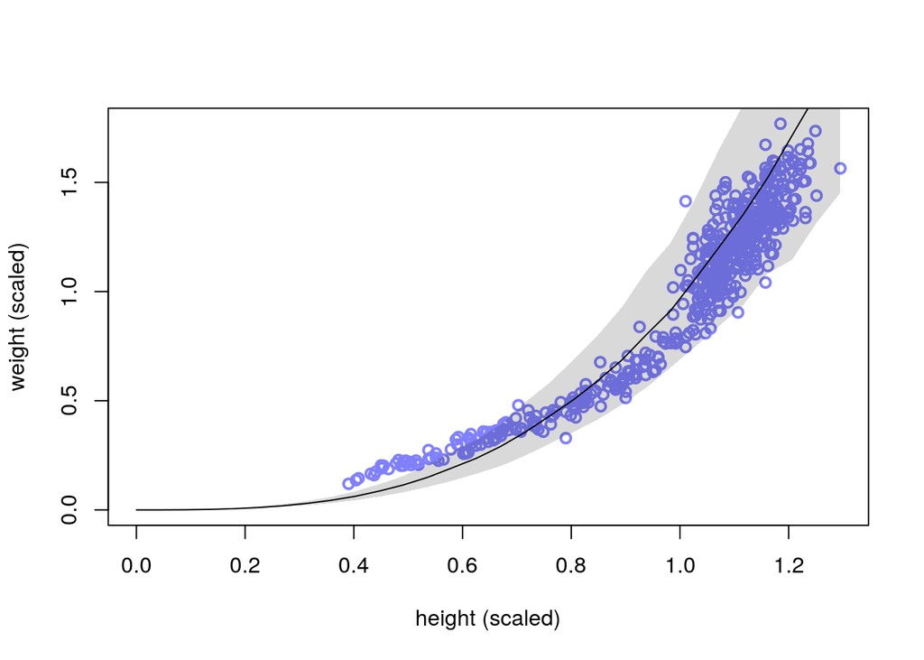

```r
plot_height <- function(model){
  h_seq <- seq( from=0 , to=max(d$h) , length.out=30 )
  w_sim <- sim( model , data=list(h=h_seq) )
  mu_mean <- apply( w_sim , 2 , mean )
  w_CI <- apply( w_sim , 2 , PI )
  plot( d$h , d$w , xlim=c(0,max(d$h)) , ylim=c(0,max(d$w)) , col=rangi2 ,
      lwd=2 , xlab="height (scaled)" , ylab="weight (scaled)" )
  lines( h_seq , mu_mean )
  shade( w_CI , h_seq )
}
plot_height(m16M1a)
```

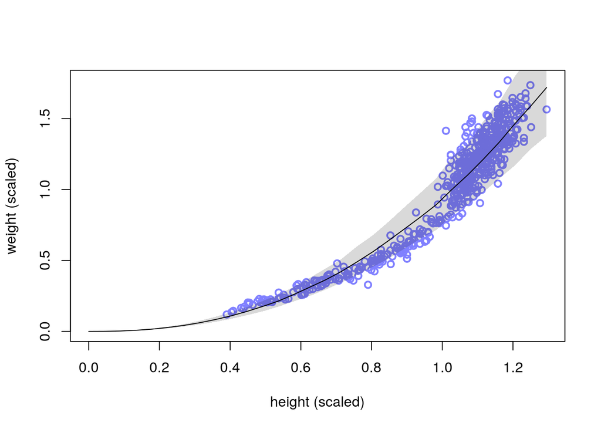

```r
plot_height(m16M1b)
```

```r
precis(m16M1b)
```

```
##            mean          sd      5.5%      94.5%     n_eff    Rhat4
## p     0.2457674 0.056499243 0.1665660  0.3414918  634.9045 1.004604
## k     5.7361596 2.705561157 2.5385376 10.7352639  624.6039 1.003614
## sigma 0.1267420 0.003902347 0.1209301  0.1331853 1103.7478 1.001823
## e     2.3573088 0.022239177 2.3225088  2.3934473 1321.2462 1.000813
```

## 16M2.

Given: 16M1.

Want: Are the priors for `m16M1a` reasonable? Suggestions.

Sol.:

```r
set.seed(1)
m16M2a <- ulam(
    alist(
        w ~ dlnorm( mu , sigma ),
        exp(mu) <- 3.141593 * k * p^2 * h^3,
        p ~ beta( 2 , 18 ),
        k ~ exponential( 0.5 ),
        sigma ~ exponential( 1 )
    ), data=d , chains=4 , cores=4 )
```

```
## recompiling to avoid crashing R session
```

```
## Trying to compile a simple C file
```

[output not shown]

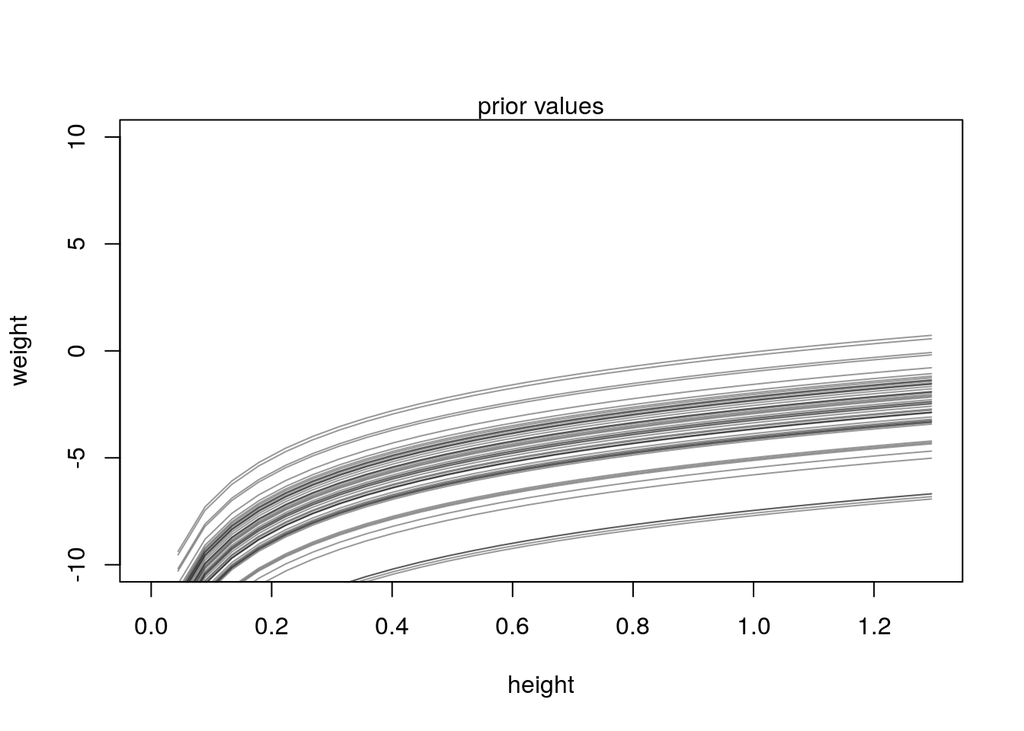

```r
plot_prior <- function(model){
  set.seed(1)
  prior <- extract.prior(model)
  h_seq <- seq( from=0 , to=max(d$h) , length.out=30 )
  mu <- link( model , post=prior, data=list(h=h_seq) )
  plot( NULL , xlim=c(0,max(d$h)) , ylim=c(-10,10), xlab="height", ylab="weight" )
  for ( i in 1:50 ) lines( h_seq , mu[i,] , col=col.alpha("black",0.4) )
  mtext("prior values")
}

plot_prior(m16M2a)
```

```r
set.seed(1)
m16M2b <- ulam(
    alist(
        w ~ dlnorm( mu , sigma ),
        exp(mu) <- 3.141593 * k * p^2 * h^3,
        p ~ beta( 10 , 10 ),
        k ~ exponential( 0.5 ),
        sigma ~ exponential( 1 )
    ), data=d , chains=4 , cores=4 )
```

```
## Trying to compile a simple C file
```

[output not shown]

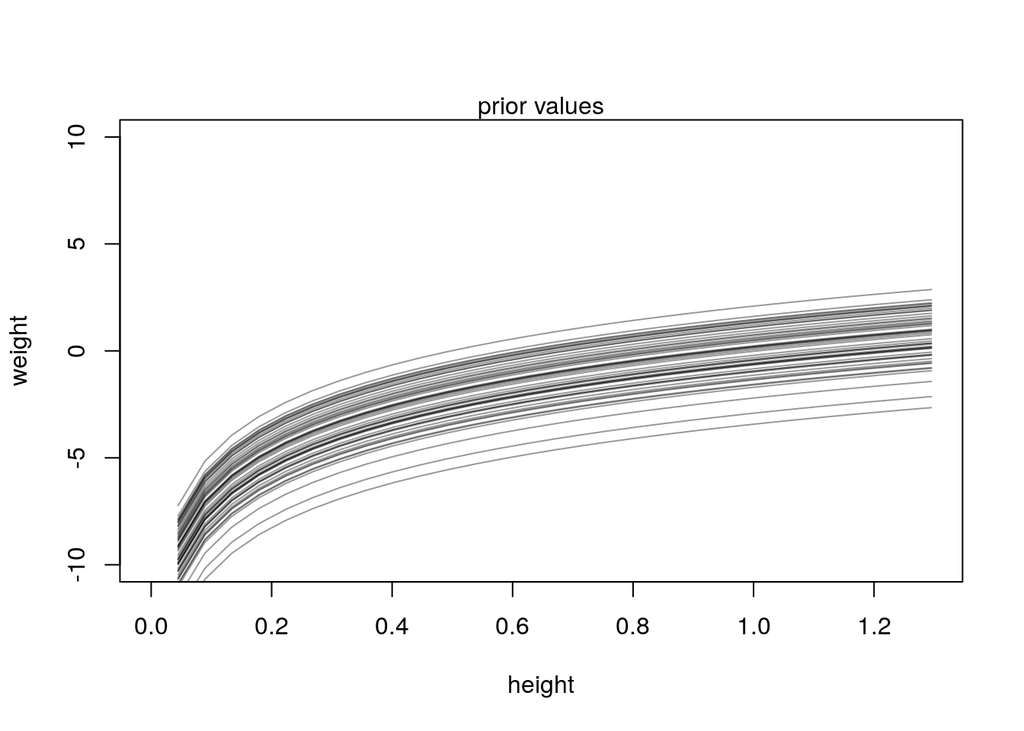

```r
plot_prior(m16M2b)
```

## 16H1.

Given: Panda nuts data. Prior to seeing the data, males are on average larger than females.

Want: Split by sex.

Sol.:

```r
data(Panda_nuts)
d <- Panda_nuts
head(d)
```

```
##   chimpanzee age sex hammer nuts_opened seconds help
## 1         11   3   m      G           0      61    N
## 2         11   3   m      G           0      37    N
## 3         18   4   f   wood           0      20    N
## 4         18   4   f      G           0      14    y
## 5         18   4   f      L           0      13    N
## 6         11   4   m      Q           0      24    N
```

```r
dat_list <- list(
    n = as.integer( Panda_nuts$nuts_opened ),
    age = Panda_nuts$age / max(Panda_nuts$age),
    seconds = Panda_nuts$seconds,
    sex = as.integer(as.factor(d$sex))
    )
```

```r
set.seed(1)
m16H1 <- ulam(
    alist(
        n ~ poisson( lambda ),
        lambda|sex==1 <- seconds*phi_f*(1-exp(-k*age))^theta,
        lambda|sex==2 <- seconds*phi_m*(1-exp(-k*age))^theta,
        phi_f ~ lognormal( log(1) , 0.1 ),
        phi_m ~ lognormal( log(2) , 0.1 ),
        k ~ lognormal( log(2) , 0.25 ),
        theta ~ lognormal( log(5) , 0.25 )
    ), data=dat_list , chains=4, cores = 4 )
```

```
## Trying to compile a simple C file
```

```r
precis(m16H1)
```

```
##            mean         sd     5.5%      94.5%     n_eff     Rhat4
## phi_f 0.8661127 0.04018656 0.804992  0.9304732 1013.1818 0.9999829
## phi_m 2.0054075 0.20222808 1.699063  2.3448734 1320.5550 0.9986753
## k     5.9776759 0.56107535 5.098024  6.8750332  844.3629 1.0016332
## theta 9.8614176 2.05217899 6.887093 13.3102463  866.5296 1.0016599
```

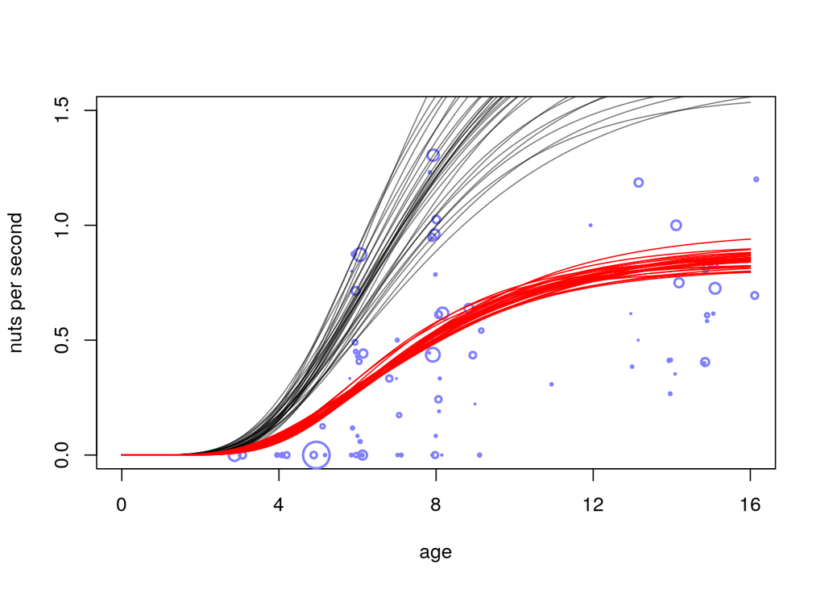

```r
post <- extract.samples(m16H1)
plot( NULL , xlim=c(0,1) , ylim=c(0,1.5) , xlab="age" ,
    ylab="nuts per second" , xaxt="n" )
at <- c(0,0.25,0.5,0.75,1,1.25,1.5)
axis( 1 , at=at , labels=round(at*max(Panda_nuts$age)) )

# raw data
pts <- dat_list$n / dat_list$seconds
point_size <- normalize( dat_list$seconds )
points( jitter(dat_list$age) , pts , col=rangi2 , lwd=2 , cex=point_size*3 )

# 30 posterior curves
for ( i in 1:30 ) with( post ,
    curve( phi_m[i]*(1-exp(-k[i]*x))^theta[i] , add=TRUE , col=grau() ) )

# 30 posterior curves
for ( i in 1:30 ) with( post ,
    curve( phi_f[i]*(1-exp(-k[i]*x))^theta[i] , add=TRUE , col=2 ) )
```

## 16H2.

Given: Panda nuts data.

Want: Vary one parameter by individual, and use partial pooling to avoid overfitting.

Sol.:

```r
dat_list <- list(
    n = as.integer( Panda_nuts$nuts_opened ),
    age = Panda_nuts$age / max(Panda_nuts$age),
    seconds = Panda_nuts$seconds,
    chimpanzee = as.integer(as.factor(d$chimpanzee))
    )
```

```r
set.seed(1)
m16H2a <- ulam(
    alist(
        n ~ poisson( lambda ),
        lambda <- seconds*phi*(1-exp(-k*age))^theta,
        phi ~ lognormal( log(1) , 0.1 ),
        k ~ lognormal( log(2) , 0.25 ),
        theta ~ lognormal( log(5) , 0.25 )
    ), data=dat_list , chains=4, cores = 4 )
```

```
## Trying to compile a simple C file
```

```r
set.seed(1)
m16H2b <- ulam(
    alist(
        n ~ poisson( lambda ),
        lambda <- seconds*phi[chimpanzee]*(1-exp(-k*age))^theta,
        phi[chimpanzee] ~ lognormal( mu_phi , sigma_phi ),
        mu_phi ~ normal(1, 0.1),
        sigma_phi ~ exponential(10),
        k ~ lognormal( log(2) , 0.25 ),
        theta ~ lognormal( log(5) , 0.25 )
    ), data=dat_list , chains=4, cores = 4 )
```

```
## Trying to compile a simple C file
```

```r
precis(m16H2b)
```

```
## 22 vector or matrix parameters hidden. Use depth=2 to show them.
```

```
##                mean         sd      5.5%    94.5%     n_eff    Rhat4
## mu_phi    0.9099984 0.09989007 0.7541778 1.072971 1287.6516 1.000300
## sigma_phi 0.8299811 0.16577705 0.6011136 1.116089  407.9904 1.003134
## k         1.1437914 0.18644044 0.8671425 1.455401  525.8687 1.003729
## theta     2.9033415 0.32801302 2.4165536 3.462582 1181.8733 1.001562
```

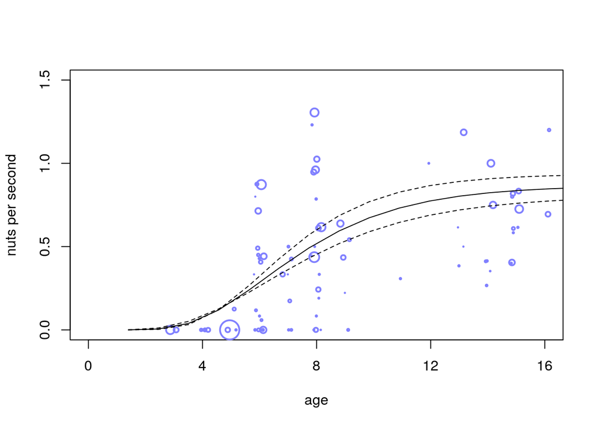

```r
post <- extract.samples(m16H2a)
plot( NULL , xlim=c(0,1) , ylim=c(0,1.5) , xlab="age" ,
    ylab="nuts per second" , xaxt="n" )
at <- c(0,0.25,0.5,0.75,1,1.25,1.5)
axis( 1 , at=at , labels=round(at*max(Panda_nuts$age)) )

# raw data
pts <- dat_list$n / dat_list$seconds
point_size <- normalize( dat_list$seconds )
points( jitter(dat_list$age) , pts , col=rangi2 , lwd=2 , cex=point_size*3 )

age_seq <- seq( from=min(dat_list$age)-0.1 , to=max(dat_list$age)+1 , length.out=30 )
phi.mean <- mean(post$phi)
k.mean <- mean(post$k)
theta.mean <- mean(post$theta)
nuts.mean <- phi.mean*(1-exp(-k.mean*age_seq))^theta.mean
lines(age_seq,nuts.mean )

phi.PI <- PI(post$phi)
k.PI <- PI(post$k)
theta.PI <- PI(post$theta)
nuts.PI_lower <- phi.PI[1]*(1-exp(-k.PI[1]*age_seq))^theta.PI[1]
nuts.PI_upper <- phi.PI[2]*(1-exp(-k.PI[2]*age_seq))^theta.PI[2]
lines(age_seq,nuts.PI_lower, lty=2)
lines(age_seq, nuts.PI_upper, lty=2)
```

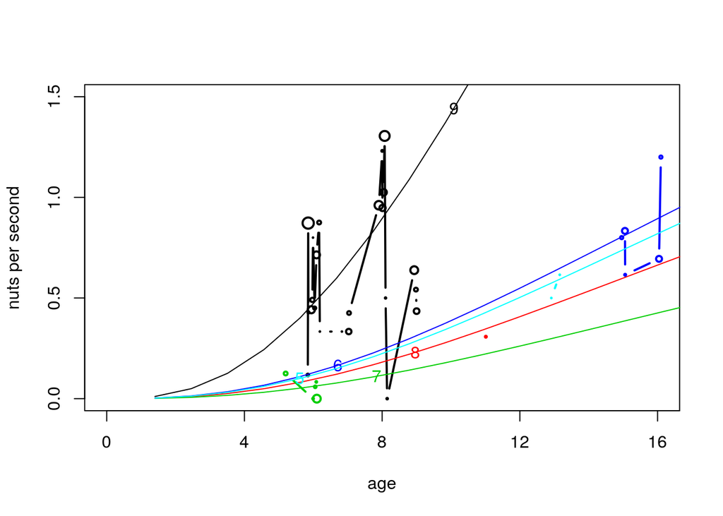

```r
plotted_chimpanzees <- c(9,8,7,6,5)

# raw data
pts <- dat_list$n / dat_list$seconds
point_size <- normalize( dat_list$seconds )
age <- jitter(dat_list$age)
chimpanzee <- dat_list$chimpanzee

post <- extract.samples(m16H2b)

phi.mat <- matrix(post$phi, nrow = 2000, ncol= 22)
k.mat <- matrix(post$k, nrow = 2000, ncol= 22)
theta.mat <- matrix(post$theta, nrow = 2000, ncol= 22)


plot( NULL , xlim=c(0,1) , ylim=c(0,1.5) , xlab="age" ,
    ylab="nuts per second" , xaxt="n" )
at <- c(0,0.25,0.5,0.75,1,1.25,1.5)
axis( 1 , at=at , labels=round(at*max(Panda_nuts$age)) )

dplot <- data.frame(pts, point_size, age, chimpanzee)
dplot <- dplot[with(dplot, order(chimpanzee, age)),]

col <- 1
for (i in plotted_chimpanzees){
  dplot_chimp <- dplot[dplot$chimpanzee==i,]
  lines(dplot_chimp$age , dplot_chimp$pts , col=col , lwd=2 , cex=dplot_chimp$point_size*3, type="b" )

  phi.mean <- mean(phi.mat[,i])
  k.mean <- mean(k.mat[,i])
  theta.mean <- mean(theta.mat[,i])
  nuts.fct <- function(age) phi.mean*(1-exp(-k.mean*age))^theta.mean
  nuts.mean <- nuts.fct(age_seq)
  lines(age_seq,nuts.mean, col=col )
  x <- i*0.07
  text(x,nuts.fct(x), labels=i, col=col)

  col <- col + 1
}
```

## 16H3.

Given: Lynx/hare data.

Want: Compare ODE model in chapter to generic lag time series.

Sol.:

```r
data(Lynx_Hare)
d <- Lynx_Hare
str(d)
```

```
## 'data.frame':    21 obs. of  3 variables:
##  $ Year: int  1900 1901 1902 1903 1904 1905 1906 1907 1908 1909 ...
##  $ Lynx: num  4 6.1 9.8 35.2 59.4 41.7 19 13 8.3 9.1 ...
##  $ Hare: num  30 47.2 70.2 77.4 36.3 20.6 18.1 21.4 22 25.4 ...
```

```r
dat_ar1 <- list(
    L = d$Lynx[2:21],
    L_lag1 = d$Lynx[1:20],
    H = d$Hare[2:21],
    H_lag1 = d$Hare[1:20] )
```

```r
set.seed(1)
m16H3a <- ulam(
    alist(
        #Lynx
        L ~ lognormal( log(mu_L), sigma ),
        mu_L <- a + b_LL*L_lag1 + b_LH*H_lag1,
        #Hare
        H ~ lognormal( log(mu_H), sigma ),
        mu_H <- a + b_HH*H_lag1 + b_HL*L_lag1,
        #priors
        c(a,b_LL, b_LH, b_HH, b_HL) ~ normal(0, 0.1),
        sigma ~ exponential(1)
    ), data=dat_ar1 , chains=4, cores=4 )
```

```
## Trying to compile a simple C file
```

```r
set.seed(1)
m16H3a.link <- link(m16H3a)
```

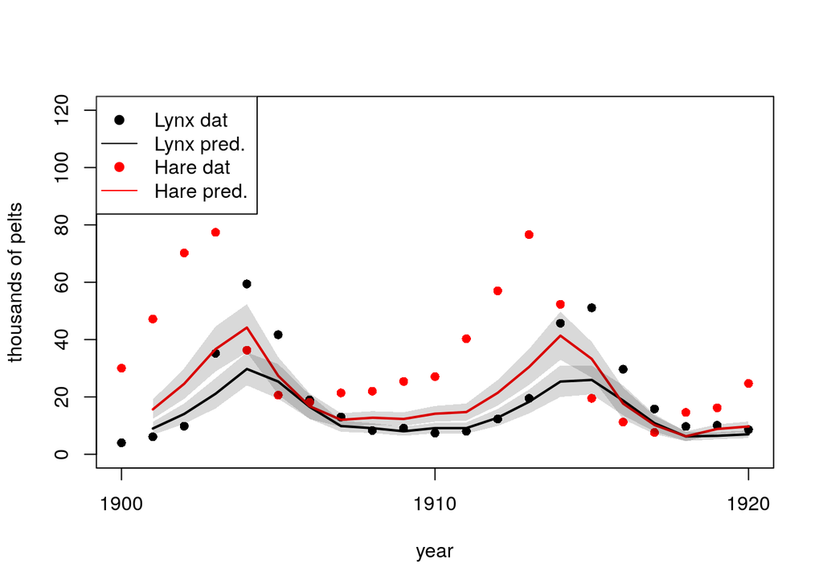

```r
plot_predictions <- function(mu_L, mu_H, years){
  L_mean <- apply(mu_L, 2, mean)
  H_mean <- apply(mu_H, 2, mean)
  L_int <- apply(mu_L, 2, PI)
  H_int <- apply(mu_H, 2, PI)

  plot( 1:21 , d$Lynx , pch=16 , ylim=c(0,120) , xlab="year" ,
    ylab="thousands of pelts" , xaxt="n", col=1 )
  at <- c(1,11,21)
  axis( 1 , at=at , labels=d$Year[at] )
  points( 1:21 , d$Hare , col=2 , pch=16 )

  lines( years , L_mean  , lwd=2, col=1 )
  lines( years , H_mean  , lwd=2, col=2 )
  shade(L_int,years)
  shade(H_int,years)

  legend("topleft", legend=c("Lynx dat", "Lynx pred.", "Hare dat","Hare pred."), col=c(1,1, 2,2), lty=c(NA,1,NA,1), pch=c(19,NA,19,NA))
}
plot_predictions(m16H3a.link$mu_L, m16H3a.link$mu_H, 2:21)
```

```r
dat_list <- list(
    N = nrow(d),
    pelts = d[,2:3] )

data(Lynx_Hare_model)
m16H3b <- stan( model_code=Lynx_Hare_model , data=dat_list , chains=4 ,
    cores=4 , control=list( adapt_delta=0.95 ) )
```

```
## Trying to compile a simple C file
```

```r
set.seed(1)
post <- extract.samples(m16H3b)
str(post)
```

```
## List of 7
##  $ theta     : num [1:4000, 1:4] 5.38 5.38 5.38 5.38 5.38 ...
##  $ pop_init  : num [1:4000, 1:2] 0.152 0.152 0.152 0.152 0.152 ...
##  $ sigma     : num [1:4000, 1:2] 0.564 0.561 0.563 0.562 0.563 ...
##  $ p         : num [1:4000, 1:2] 0.584 0.584 0.584 0.584 0.583 ...
##  $ pop       : num [1:4000, 1:21, 1:2] 0.152 0.152 0.152 0.152 0.152 ...
##  $ pelts_pred: num [1:4000, 1:21, 1:2] 0.1018 0.0963 0.082 0.0556 0.0512 ...
##  $ lp__      : num [1:4000(1d)] -2902 -2925 -2906 -2924 -2907 ...
```

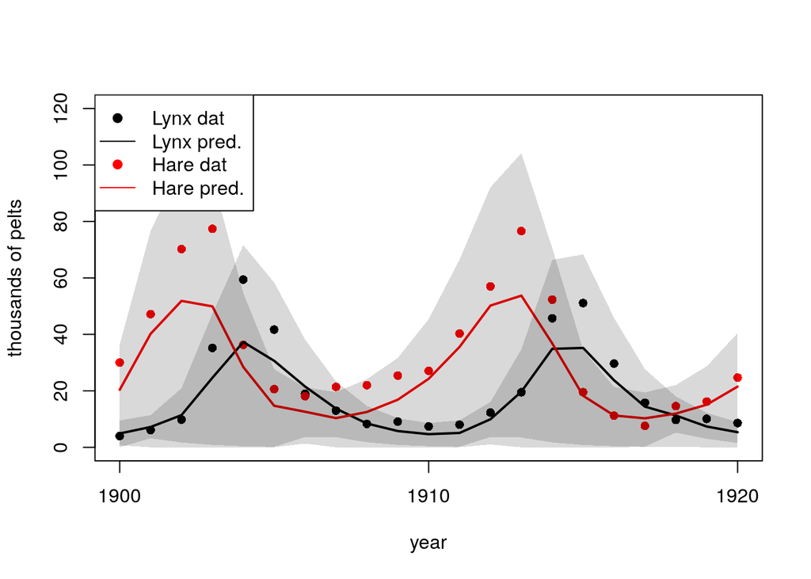

```r
plot_predictions(post$pelts_pred[,,1], post$pelts_pred[,,2], 1:21)
```

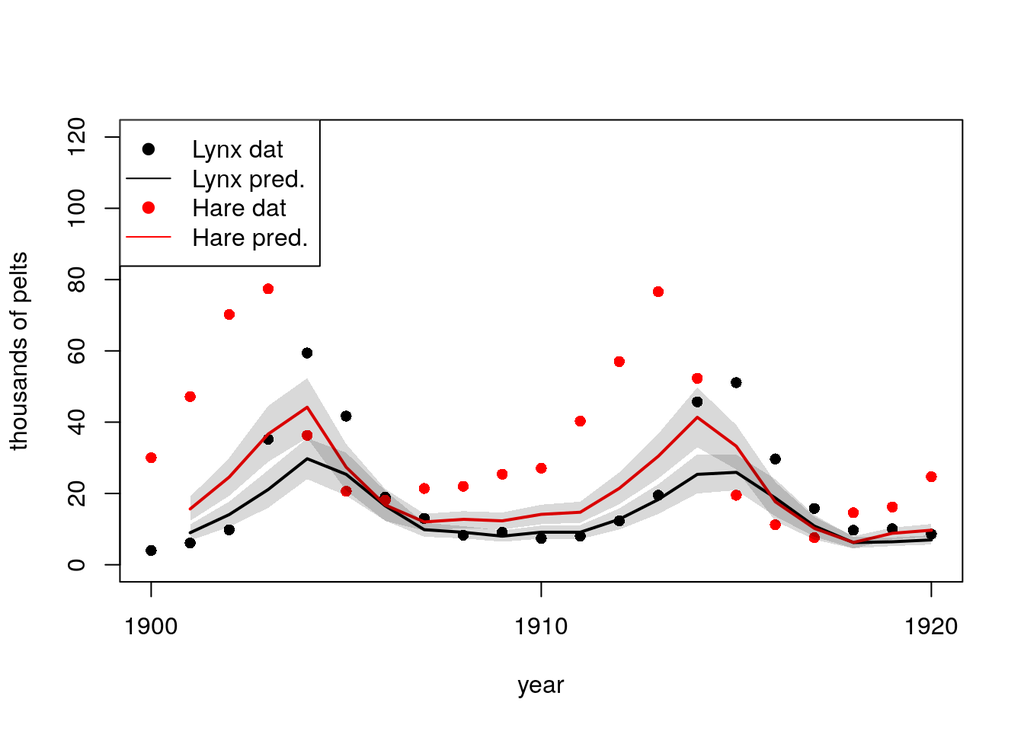

```r
plot_predictions(m16H3a.link$mu_L, m16H3a.link$mu_H, 2:21)
```

- The prediction by the lag time series model fits poorly. The peeks are generally to low.
- Lag time series model/using only the last data points is too simple for this kind of dynamic.

## 16H4.

Given: 16H3.

Want: Fit autoregressive model with two-step lag variable.

Sol.:

```r
dat_ar2 <- list(
    L = d$Lynx[3:21],
    L_lag1 = d$Lynx[2:20],
    L_lag2 = d$Lynx[1:19],
    H = d$Hare[3:21],
    H_lag1 = d$Hare[2:20],
    H_lag2 = d$Lynx[1:19])
```

```r
set.seed(1)
m16H4 <- ulam(
    alist(
        #Lynx
        L ~ lognormal( log(mu_L), sigma ),
        mu_L <- a + b_LL*L_lag1 + b_LH*H_lag1 + b_LL2*L_lag2 + b_LH2*H_lag2,
        #Hare
        H ~ lognormal( log(mu_H), sigma ),
        mu_H <- a + b_HH*H_lag1 + b_HL*L_lag1 + b_HH2*H_lag2 + b_HL2*L_lag2,
        #priors
        c(a,b_LL, b_LH, b_HH, b_HL,b_LL2, b_LH2, b_HH2, b_HL2) ~ normal(0, 0.1),
        sigma ~ exponential(1)
    ), data=dat_ar2 , chains=4, cores=4 )
```

```
## Trying to compile a simple C file
```

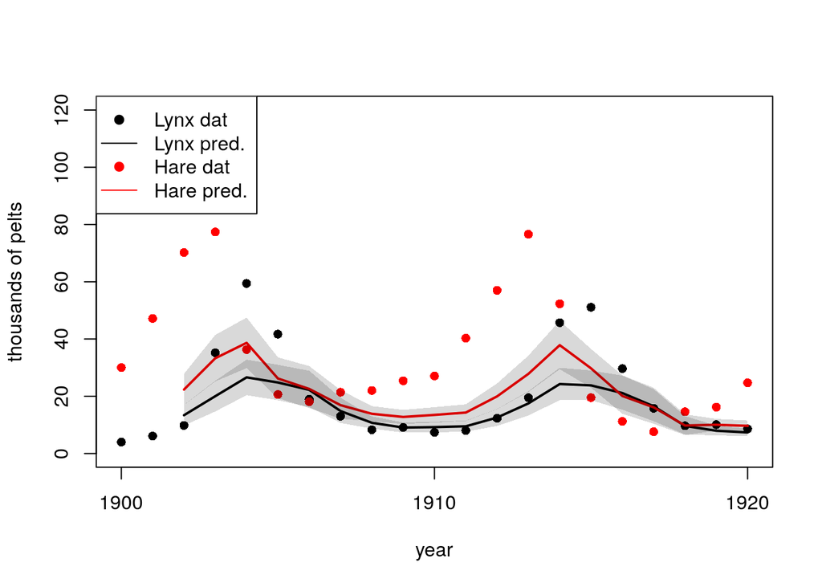

```r
set.seed(1)
m16H4.link <- link(m16H4)
plot_predictions(m16H4.link$mu_L, m16H4.link$mu_H, 3:21)
```

- It has not improved.

## 16H5.

Given: Mites data.

Want: Model with Lotka-Volterra ODE. (Modify `Lynx_Hare_model`)

Sol.:

```r
data("Mites")
d <- Mites
summary(d)
```

```
##       day             prey           predator
##  Min.   : 16.0   Min.   :  40.0   Min.   :  50.0
##  1st Qu.: 71.5   1st Qu.: 201.5   1st Qu.:  77.5
##  Median :127.0   Median : 572.0   Median : 154.0
##  Mean   :127.1   Mean   : 855.2   Mean   : 306.1
##  3rd Qu.:182.0   3rd Qu.:1607.0   3rd Qu.: 465.5
##  Max.   :238.0   Max.   :2100.0   Max.   :1209.0
```

```r
dat_list <- list(
    N = nrow(d),
    pelts = d[,2:3] )

m16H5 <- stan( model_code=Lynx_Hare_model , data=dat_list , chains=4 ,
    cores=4 , control=list( adapt_delta=0.95 ) )
```

```r
set.seed(1)
post <- extract.samples(m16H5)
str(post)
```

```
## List of 7
##  $ theta     : num [1:4000, 1:4] 0.997 1.108 1.926 1.666 1.139 ...
##  $ pop_init  : num [1:4000, 1:2] 1289 1912 1044 1368 1213 ...
##  $ sigma     : num [1:4000, 1:2] 1.72 1.18 1.74 1.72 1.46 ...
##  $ p         : num [1:4000, 1:2] 0.204 0.189 0.206 0.166 0.226 ...
##  $ pop       : num [1:4000, 1:35, 1:2] 1289 1912 1044 1368 1213 ...
##  $ pelts_pred: num [1:4000, 1:35, 1:2] 189.4 34.9 858.4 2740.8 396.1 ...
##  $ lp__      : num [1:4000(1d)] -288 -287 -286 -289 -292 ...
```

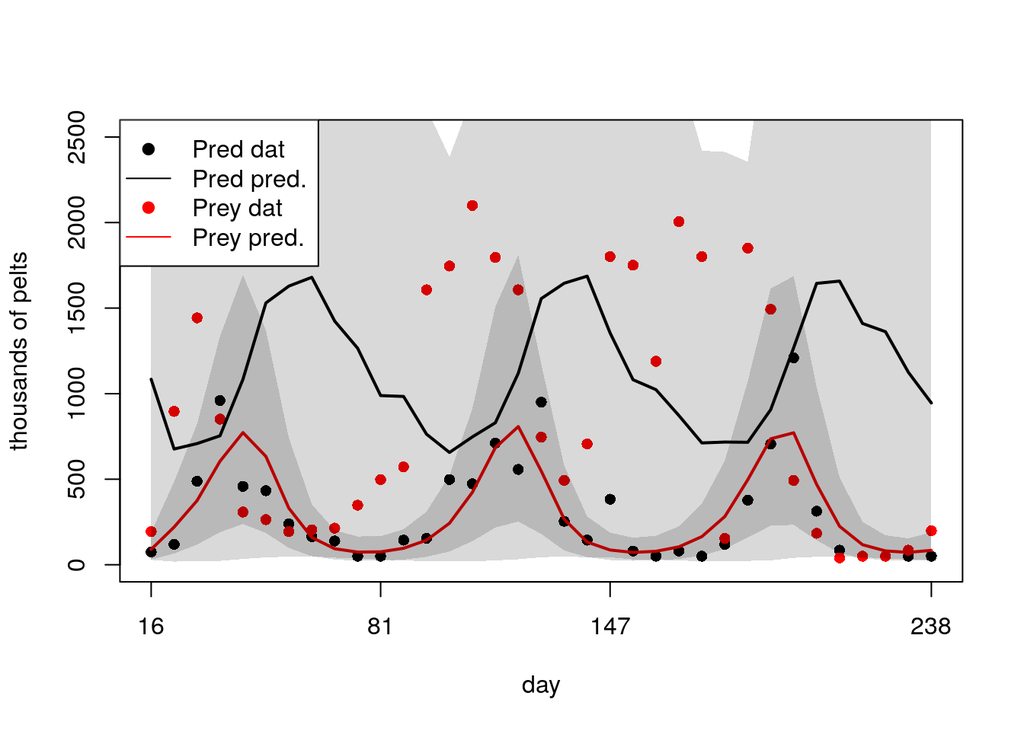

```r
plot_predictions <- function(mu_L, mu_H, days){
  L_mean <- apply(mu_L, 2, mean)
  H_mean <- apply(mu_H, 2, mean)
  L_int <- apply(mu_L, 2, PI)
  H_int <- apply(mu_H, 2, PI)

  plot( days , d$predator , pch=16 , ylim=c(0, 2500), xlab="day" ,
    ylab="thousands of pelts" , xaxt="n", col=1 )
  at <- c(1,11,21,35)
  axis( 1 , at=at , labels=d$day[at] )
  points( days , d$prey , col=2 , pch=16 )

  lines( days , L_mean  , lwd=2, col=1 )
  lines( days , H_mean  , lwd=2, col=2 )
  shade(L_int,days)
  shade(H_int,days)

  legend("topleft", legend=c("Pred dat", "Pred pred.", "Prey dat","Prey pred."), col=c(1,1, 2,2), lty=c(NA,1,NA,1), pch=c(19,NA,19,NA))
}
plot_predictions(post$pelts_pred[,,1], post$pelts_pred[,,2], 1:nrow(d))
```